# Air Pollution and State Political Allignment Data Analysis

```python
%matplotlib inline

import numpy as np
import pandas as pd

import matplotlib.pyplot as plt
import plotly.plotly as py
import seaborn as sns
import patsy

import requests
import bs4
from bs4 import BeautifulSoup
```

```python
airData = pd.read_csv("annual_aqi_by_county_2017.csv")
```

```python
from IPython.display import HTML
from IPython.display import display

import plotly
```

Retrieving plotly username and api key credentials.

## Cleaning/Getting Data

Look at average for each state

```python
avgData = airData.drop('County', axis=1)
avgData = avgData.groupby('State', as_index=False).mean()
avgData.head()
```

|  | State | Year | Days with AQI | Good Days | Moderate Days | Unhealthy for Sensitive Groups Days | Unhealthy Days | Very Unhealthy Days | Hazardous Days | Max AQI | 90th Percentile AQI | Median AQI | Days CO | Days NO2 | Days Ozone | Days SO2 | Days PM2.5 | Days PM10 |
| --- | --- | --- | --- | --- | --- | --- | --- | --- | --- | --- | --- | --- | --- | --- | --- | --- | --- | --- |
| 0 | Alabama | 2017.0 | 289.000000 | 228.833333 | 58.888889 | 1.166667 | 0.055556 | 0.055556 | 0.000000 | 104.666667 | 54.500000 | 38.166667 | 0.000000 | 0.111111 | 153.444444 | 10.888889 | 121.500000 | 3.055556 |
| 1 | Alaska | 2017.0 | 267.714286 | 227.857143 | 32.428571 | 4.428571 | 3.000000 | 0.000000 | 0.000000 | 90.571429 | 50.714286 | 22.000000 | 0.857143 | 1.428571 | 98.571429 | 0.000000 | 141.285714 | 25.571429 |
| 2 | Arizona | 2017.0 | 360.846154 | 219.538462 | 118.153846 | 20.153846 | 2.769231 | 0.153846 | 0.076923 | 151.769231 | 74.384615 | 47.153846 | 0.000000 | 1.538462 | 193.692308 | 19.769231 | 30.769231 | 115.076923 |
| 3 | Arkansas | 2017.0 | 274.636364 | 226.363636 | 48.090909 | 0.181818 | 0.000000 | 0.000000 | 0.000000 | 84.090909 | 53.181818 | 37.000000 | 0.000000 | 0.818182 | 141.545455 | 0.000000 | 132.272727 | 0.000000 |
| 4 | California | 2017.0 | 356.037736 | 203.792453 | 118.509434 | 25.207547 | 6.962264 | 1.018868 | 0.207547 | 286.679245 | 88.566038 | 49.188679 | 0.000000 | 3.830189 | 214.056604 | 0.018868 | 120.188679 | 17.943396 |

```python
stateAbbreviations = pd.read_csv("https://raw.githubusercontent.com/jasonong/List-of-US-States/master/states.csv")
stateAbbreviations.head()
```

|  | State | Abbreviation |
| --- | --- | --- |
| 0 | Alabama | AL |
| 1 | Alaska | AK |
| 2 | Arizona | AZ |
| 3 | Arkansas | AR |
| 4 | California | CA |

```python
avgData = pd.merge(stateAbbreviations, avgData, how='inner', on='State')
avgData.head()
```

|  | State | Abbreviation | Year | Days with AQI | Good Days | Moderate Days | Unhealthy for Sensitive Groups Days | Unhealthy Days | Very Unhealthy Days | Hazardous Days | Max AQI | 90th Percentile AQI | Median AQI | Days CO | Days NO2 | Days Ozone | Days SO2 | Days PM2.5 | Days PM10 |
| --- | --- | --- | --- | --- | --- | --- | --- | --- | --- | --- | --- | --- | --- | --- | --- | --- | --- | --- | --- |
| 0 | Alabama | AL | 2017.0 | 289.000000 | 228.833333 | 58.888889 | 1.166667 | 0.055556 | 0.055556 | 0.000000 | 104.666667 | 54.500000 | 38.166667 | 0.000000 | 0.111111 | 153.444444 | 10.888889 | 121.500000 | 3.055556 |
| 1 | Alaska | AK | 2017.0 | 267.714286 | 227.857143 | 32.428571 | 4.428571 | 3.000000 | 0.000000 | 0.000000 | 90.571429 | 50.714286 | 22.000000 | 0.857143 | 1.428571 | 98.571429 | 0.000000 | 141.285714 | 25.571429 |
| 2 | Arizona | AZ | 2017.0 | 360.846154 | 219.538462 | 118.153846 | 20.153846 | 2.769231 | 0.153846 | 0.076923 | 151.769231 | 74.384615 | 47.153846 | 0.000000 | 1.538462 | 193.692308 | 19.769231 | 30.769231 | 115.076923 |
| 3 | Arkansas | AR | 2017.0 | 274.636364 | 226.363636 | 48.090909 | 0.181818 | 0.000000 | 0.000000 | 0.000000 | 84.090909 | 53.181818 | 37.000000 | 0.000000 | 0.818182 | 141.545455 | 0.000000 | 132.272727 | 0.000000 |
| 4 | California | CA | 2017.0 | 356.037736 | 203.792453 | 118.509434 | 25.207547 | 6.962264 | 1.018868 | 0.207547 | 286.679245 | 88.566038 | 49.188679 | 0.000000 | 3.830189 | 214.056604 | 0.018868 | 120.188679 | 17.943396 |

```python
wiki = 'https://en.wikipedia.org/wiki/List_of_U.S._states_and_territories_by_population'
page = requests.get(wiki)
soup = BeautifulSoup(page.content, 'html.parser')
```

```python
right_table = soup.find('table', class_='wikitable sortable')
```

```python
lst_a, lst_b= [], []

for row in right_table.findAll('tr'):

    cells = row.findAll('td')
    if len(cells) != 11:
        continue

    # This catches when the name cells stops having a link
    #  and ends, skipping the last (summary rows)
    try:

        lst_a.append(cells[2].find('a').text)
        lst_b.append(cells[3].find(text=True))
    except:
        break
```

```python
popDF = pd.DataFrame()
popDF['State'] = lst_a
popDF['Population Estimate'] = lst_b
popDF['Population Estimate'] = popDF['Population Estimate'].replace('\n','', regex=True)
popDF['Population Estimate'] = popDF['Population Estimate'].replace(',','', regex=True)
```

```python
avgData = pd.merge(popDF, avgData, how='inner', on='State')
```

```python
avgData['Population Estimate'] = avgData['Population Estimate'].astype(float)
```

```python
avgData['Unhealthy or Worse Days'] = avgData['Unhealthy Days']+avgData['Very Unhealthy Days']+ avgData['Hazardous Days']
avgData.head()
```

|  | State | Population Estimate | Abbreviation | Year | Days with AQI | Good Days | Moderate Days | Unhealthy for Sensitive Groups Days | Unhealthy Days | Very Unhealthy Days | ... | Max AQI | 90th Percentile AQI | Median AQI | Days CO | Days NO2 | Days Ozone | Days SO2 | Days PM2.5 | Days PM10 | Unhealthy or Worse Days |
| --- | --- | --- | --- | --- | --- | --- | --- | --- | --- | --- | --- | --- | --- | --- | --- | --- | --- | --- | --- | --- | --- |
| 0 | California | 39536653.0 | CA | 2017.0 | 356.037736 | 203.792453 | 118.509434 | 25.207547 | 6.962264 | 1.018868 | ... | 286.679245 | 88.566038 | 49.188679 | 0.000000 | 3.830189 | 214.056604 | 0.018868 | 120.188679 | 17.943396 | 8.188679 |
| 1 | Texas | 28304596.0 | TX | 2017.0 | 331.653061 | 273.551020 | 52.775510 | 4.693878 | 0.632653 | 0.000000 | ... | 114.408163 | 56.000000 | 32.836735 | 0.020408 | 3.204082 | 179.510204 | 43.326531 | 105.448980 | 0.142857 | 0.632653 |
| 2 | Florida | 20984400.0 | FL | 2017.0 | 355.384615 | 307.000000 | 47.282051 | 1.102564 | 0.000000 | 0.000000 | ... | 105.846154 | 52.512821 | 36.897436 | 0.179487 | 1.128205 | 227.641026 | 3.512821 | 112.794872 | 10.128205 | 0.000000 |
| 3 | New York | 19849399.0 | NY | 2017.0 | 352.322581 | 317.419355 | 32.709677 | 2.096774 | 0.096774 | 0.000000 | ... | 99.225806 | 49.096774 | 31.645161 | 0.032258 | 9.129032 | 232.709677 | 33.096774 | 77.290323 | 0.064516 | 0.096774 |
| 4 | Pennsylvania | 12805537.0 | PA | 2017.0 | 361.842105 | 269.526316 | 89.763158 | 2.394737 | 0.157895 | 0.000000 | ... | 108.894737 | 59.000000 | 40.684211 | 0.000000 | 1.631579 | 211.368421 | 11.131579 | 136.315789 | 1.394737 | 0.157895 |

5 rows × 21 columns

```python
avgData['Median AQI per million people'] = avgData['Median AQI']/avgData['Population Estimate'] * 1000000
avgData['Days PM2.5 per million people'] = avgData['Days PM2.5']/avgData['Population Estimate'] * 1000000
```

## Exploratory Graphs

### Graph of days that are considered unhealthy and worse.

```python
avgStrDta = avgData.copy()
```

```python
for col in avgStrDta.columns:
    avgStrDta[col] = avgStrDta[col].astype(str)
```

```python
scl = [[0.0, 'rgb(242,240,247)'],[0.2, 'rgb(218,218,235)'],[0.4, 'rgb(188,189,220)'],\
            [0.6, 'rgb(158,154,200)'],[0.8, 'rgb(117,107,177)'],[1.0, 'rgb(84,39,143)']]

avgStrDta['text'] = avgStrDta['State'] + '<br>' +\
    'Unhealthy days: '+avgStrDta['Unhealthy Days'] + '<br>' +\
    'Very Unhealthy Days: ' +avgStrDta['Very Unhealthy Days'] + '<br>'+\
    'Hazardous Days: '+avgStrDta['Hazardous Days']
```

```python
data = [ dict(
        type='choropleth',
        colorscale = scl,
        autocolorscale = False,
        locations = avgStrDta['Abbreviation'],
        z = avgStrDta['Unhealthy or Worse Days'].astype(float),
        locationmode = 'USA-states',
        text = avgStrDta['text'],
        marker = dict(
            line = dict (
                color = 'rgb(255,255,255)',
                width = 2
            ) ),
        colorbar = dict(
            title = "Average Days")
        ) ]
```

```python
layout = dict(
        title = '2017 US Unhealthy or Worse Days by State<br>(Hover for breakdown)',
        geo = dict(
            scope='usa',
            projection=dict( type='albers usa' ),
            showlakes = True,
            lakecolor = 'rgb(255, 255, 255)'),
             )
```

```python
#py.tools.set_credentials_file(username='LilArveen', api_key='KbGcu7YS02M71TS8ZQxk')
fig = dict( data=data, layout=layout )
py.iplot( fig, filename='d3-cloropleth-map' )
```

```
High five! You successfully sent some data to your account on plotly. View your plot in your browser at https://plot.ly/~LilArveen/0 or inside your plot.ly account where it is named 'd3-cloropleth-map'
```

[interactive chart not shown]

As you can see above, while most western states typically have worse days than eastern states, Hawaii is way off the charts. This may be due to the fact that Hawaii has an active volcano known as Kileauea.

Thus, in order to have a better sense of what is happening in other states, I will disregard Hawaii for now

```python
noHawaii = avgStrDta.copy()
cols = [col for col in noHawaii.columns if col != 'Abbreviation']
noHawaii.loc[noHawaii['Abbreviation'] == 'HI', cols ] = '0'

data = [ dict(
        type='choropleth',
        colorscale = scl,
        autocolorscale = False,
        locations = noHawaii['Abbreviation'],
        z = noHawaii['Unhealthy or Worse Days'].astype(float),
        locationmode = 'USA-states',
        text = noHawaii['text'],
        marker = dict(
            line = dict (
                color = 'rgb(255,255,255)',
                width = 2
            ) ),
        colorbar = dict(
            title = "Average Days")
        ) ]

layout = dict(
        title = '2017 US Unhealthy or Worse Days by State without Hawaii <br>(Hover for breakdown)',
        geo = dict(
            scope='usa',
            projection=dict( type='albers usa' ),
            showlakes = True,
            lakecolor = 'rgb(255, 255, 255)'),
             )

fig = dict( data=data, layout=layout )
py.iplot( fig, filename='noHawaii-cloropleth-map' )
```

[interactive chart not shown]

Western states seem to have more unhealthy days, but that may be due to the fact that wildfires are far more common along the west coast than the east coast.

### Days PM2.5 per million people

```python
avgStrDta['text'] = avgStrDta['State'] + '<br>' +\
    'PM2.5 Days per million people: '+avgStrDta['Days PM2.5 per million people']
```

```python
data = [ dict(
        type='choropleth',
        colorscale = scl,
        autocolorscale = False,
        locations = avgStrDta['Abbreviation'],
        z = avgStrDta['Days PM2.5 per million people'].astype(float),
        locationmode = 'USA-states',
        text = avgStrDta['text'],
        marker = dict(
            line = dict (
                color = 'rgb(255,255,255)',
                width = 2
            ) ),
        colorbar = dict(
            title = "Average Days")
        ) ]

layout = dict(
        title = '2017 US Days PM2.5 per million people by State<br>(Hover for breakdown)',
        geo = dict(
            scope='usa',
            projection=dict( type='albers usa' ),
            showlakes = True,
            lakecolor = 'rgb(255, 255, 255)'),
             )
```

```python
fig = dict( data=data, layout=layout )
py.iplot( fig, filename='DaysPM2.5-cloropleth-map' )
```

[interactive chart not shown]

### Median AQI per million people

```python
avgStrDta['text'] = avgStrDta['State'] + '<br>' +\
    'Median AQI Days per million people: '+avgStrDta['Median AQI per million people']
```

```python
data = [ dict(
        type='choropleth',
        colorscale = scl,
        autocolorscale = False,
        locations = avgStrDta['Abbreviation'],
        z = avgStrDta['Median AQI per million people'].astype(float),
        locationmode = 'USA-states',
        text = avgStrDta['text'],
        marker = dict(
            line = dict (
                color = 'rgb(255,255,255)',
                width = 2
            ) ),
        colorbar = dict(
            title = "Average Days")
        ) ]

layout = dict(
        title = '2017 US Median AQI per million people by State<br>(Hover for breakdown)',
        geo = dict(
            scope='usa',
            projection=dict( type='albers usa' ),
            showlakes = True,
            lakecolor = 'rgb(255, 255, 255)'),
             )
```

```python
fig = dict( data=data, layout=layout )
py.iplot( fig, filename='MedianAQI-cloropleth-map' )
```

[interactive chart not shown]

## Correlation of Pollution levels and political orientation

### Assigning Red, Blue, or purple based off how the state went in the past 4 elections

```python
politicalAllignment  = pd.read_csv("Political Allignment.csv")
```

```python
avgData = pd.merge(politicalAllignment, avgData, how='inner', on='Abbreviation')
```

```python
avgData.head()
```

|  | Abbreviation | Political Allignment | State | Population Estimate | Year | Days with AQI | Good Days | Moderate Days | Unhealthy for Sensitive Groups Days | Unhealthy Days | ... | Median AQI | Days CO | Days NO2 | Days Ozone | Days SO2 | Days PM2.5 | Days PM10 | Unhealthy or Worse Days | Median AQI per million people | Days PM2.5 per million people |
| --- | --- | --- | --- | --- | --- | --- | --- | --- | --- | --- | --- | --- | --- | --- | --- | --- | --- | --- | --- | --- | --- |
| 0 | AL | R | Alabama | 4874747.0 | 2017.0 | 289.000000 | 228.833333 | 58.888889 | 1.166667 | 0.055556 | ... | 38.166667 | 0.000000 | 0.111111 | 153.444444 | 10.888889 | 121.500000 | 3.055556 | 0.111111 | 7.829466 | 24.924370 |
| 1 | AK | R | Alaska | 739795.0 | 2017.0 | 267.714286 | 227.857143 | 32.428571 | 4.428571 | 3.000000 | ... | 22.000000 | 0.857143 | 1.428571 | 98.571429 | 0.000000 | 141.285714 | 25.571429 | 3.000000 | 29.737968 | 190.979547 |
| 2 | AZ | R | Arizona | 7016270.0 | 2017.0 | 360.846154 | 219.538462 | 118.153846 | 20.153846 | 2.769231 | ... | 47.153846 | 0.000000 | 1.538462 | 193.692308 | 19.769231 | 30.769231 | 115.076923 | 3.000000 | 6.720643 | 4.385411 |
| 3 | AR | R | Arkansas | 3004279.0 | 2017.0 | 274.636364 | 226.363636 | 48.090909 | 0.181818 | 0.000000 | ... | 37.000000 | 0.000000 | 0.818182 | 141.545455 | 0.000000 | 132.272727 | 0.000000 | 0.000000 | 12.315767 | 44.028110 |
| 4 | CA | D | California | 39536653.0 | 2017.0 | 356.037736 | 203.792453 | 118.509434 | 25.207547 | 6.962264 | ... | 49.188679 | 0.000000 | 3.830189 | 214.056604 | 0.018868 | 120.188679 | 17.943396 | 8.188679 | 1.244129 | 3.039931 |

5 rows × 24 columns

```python
avgDataPolitical = avgData.groupby('Political Allignment', as_index=False).mean()
```

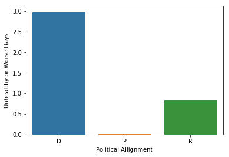

```python
sns.barplot(x="Political Allignment", y="Unhealthy or Worse Days", data = avgDataPolitical)
```

While the above bar seems to show that Democratic states tend to have unhealthy or worse days more often than republican states it does not take into the fact that most Democratic states either have more population, or have more wild fires on average(states like California, etc) when compared to red states.

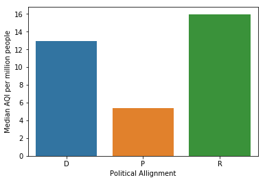

```python
sns.barplot(x="Political Allignment", y="Median AQI per million people", data = avgDataPolitical)
```

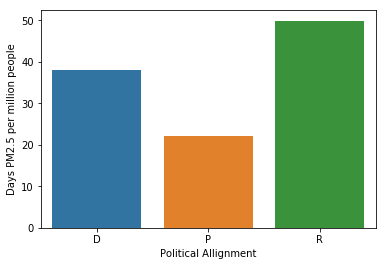

```python
sns.barplot(x="Political Allignment", y="Days PM2.5 per million people", data = avgDataPolitical)
```

As we can see, when we take population into account, republican states tend to be more polluted per million people.

However, does political allignemnet help determine the days where the particulate matter(PM) is above 2.5? Does it also help determine the median AQI?

```python
import statsmodels.api as sm
import scipy.stats as stats
```

```python
avgData['PoliticalNumber'] = np.where(avgData['Political Allignment']=='D', 1,np.where(avgData['Political Allignment'] == 'R', -1, 0))
avgData.drop(['State', 'Abbreviation', 'Year'], axis=1, inplace=True)
```

```python
x = avgData.loc[:,avgData.columns!='Days PM2.5 per million people']
x = x.loc[:, x.columns !='Median AQI per million people']
x = x.loc[:, x.columns !='Political Allignment']
y = avgData['Days PM2.5 per million people']
model = sm.OLS(y, x.astype(float)).fit()

print(model.summary())
```

```
                                  OLS Regression Results
=========================================================================================
Dep. Variable:     Days PM2.5 per million people   R-squared:                       0.876
Model:                                       OLS   Adj. R-squared:                  0.813
Method:                            Least Squares   F-statistic:                     13.77
Date:                           Sat, 22 Sep 2018   Prob (F-statistic):           2.11e-10
Time:                                   12:32:46   Log-Likelihood:                -227.58
No. Observations:                             50   AIC:                             489.2
Df Residuals:                                 33   BIC:                             521.7
Df Model:                                     17
Covariance Type:                       nonrobust
=======================================================================================================
                                          coef    std err          t      P>|t|      [0.025      0.975]
-------------------------------------------------------------------------------------------------------
Population Estimate                 -4.717e-06   8.66e-07     -5.448      0.000   -6.48e-06   -2.96e-06
Days with AQI                         417.9800    149.828      2.790      0.009     113.153     722.807
Good Days                            -472.5262    175.484     -2.693      0.011    -829.552    -115.501
Moderate Days                        -472.6786    175.439     -2.694      0.011    -829.611    -115.746
Unhealthy for Sensitive Groups Days  -467.3804    175.338     -2.666      0.012    -824.108    -110.652
Unhealthy Days                       -120.6360     38.940     -3.098      0.004    -199.860     -41.412
Very Unhealthy Days                  -163.7545     64.739     -2.529      0.016    -295.466     -32.043
Hazardous Days                        -68.3022     75.546     -0.904      0.372    -222.002      85.397
Max AQI                                -0.2569      0.304     -0.844      0.405      -0.876       0.362
90th Percentile AQI                    -0.7698      1.626     -0.474      0.639      -4.077       2.537
Median AQI                             -3.2135      2.039     -1.576      0.125      -7.361       0.934
Days CO                               143.2607     31.683      4.522      0.000      78.802     207.719
Days NO2                               53.9743     26.310      2.051      0.048       0.447     107.502
Days Ozone                             55.2252     26.094      2.116      0.042       2.137     108.313
Days SO2                               55.0623     26.161      2.105      0.043       1.837     108.287
Days PM2.5                             55.5488     26.142      2.125      0.041       2.362     108.736
Days PM10                              54.9087     26.106      2.103      0.043       1.796     108.022
Unhealthy or Worse Days              -352.6927    138.451     -2.547      0.016    -634.374     -71.011
PoliticalNumber                        -9.9078      5.190     -1.909      0.065     -20.466       0.651
==============================================================================
Omnibus:                        0.258   Durbin-Watson:                   2.483
Prob(Omnibus):                  0.879   Jarque-Bera (JB):                0.372
Skew:                           0.154   Prob(JB):                        0.830
Kurtosis:                       2.712   Cond. No.                     2.61e+22
==============================================================================

Warnings:
[1] Standard Errors assume that the covariance matrix of the errors is correctly specified.
[2] The smallest eigenvalue is 6.98e-30. This might indicate that there are
strong multicollinearity problems or that the design matrix is singular.
```

While we can see that the p value for political number is pretty low, it is still not statstically significant since the p value is still over 0.05.

```python
y = avgData['Median AQI per million people']
model = sm.OLS(y, x.astype(float)).fit()

print(model.summary())
```

```
                                  OLS Regression Results
=========================================================================================
Dep. Variable:     Median AQI per million people   R-squared:                       0.845
Model:                                       OLS   Adj. R-squared:                  0.765
Method:                            Least Squares   F-statistic:                     10.55
Date:                           Sat, 22 Sep 2018   Prob (F-statistic):           7.21e-09
Time:                                   12:32:46   Log-Likelihood:                -174.14
No. Observations:                             50   AIC:                             382.3
Df Residuals:                                 33   BIC:                             414.8
Df Model:                                     17
Covariance Type:                       nonrobust
=======================================================================================================
                                          coef    std err          t      P>|t|      [0.025      0.975]
-------------------------------------------------------------------------------------------------------
Population Estimate                 -1.469e-06   2.97e-07     -4.941      0.000   -2.07e-06   -8.64e-07
Days with AQI                         116.5681     51.456      2.265      0.030      11.881     221.255
Good Days                            -132.7273     60.267     -2.202      0.035    -255.341     -10.113
Moderate Days                        -132.5750     60.251     -2.200      0.035    -255.157      -9.993
Unhealthy for Sensitive Groups Days  -133.5299     60.217     -2.217      0.034    -256.042     -11.018
Unhealthy Days                        -26.8549     13.373     -2.008      0.053     -54.063       0.353
Very Unhealthy Days                   -45.4404     22.233     -2.044      0.049     -90.674      -0.206
Hazardous Days                        -31.6016     25.945     -1.218      0.232     -84.387      21.184
Max AQI                                 0.1783      0.105      1.706      0.097      -0.034       0.391
90th Percentile AQI                    -0.4584      0.558     -0.821      0.417      -1.594       0.677
Median AQI                             -0.6781      0.700     -0.968      0.340      -2.103       0.746
Days CO                                35.6095     10.881      3.273      0.003      13.472      57.747
Days NO2                               15.9009      9.036      1.760      0.088      -2.482      34.284
Days Ozone                             16.3371      8.961      1.823      0.077      -1.895      34.569
Days SO2                               16.2606      8.985      1.810      0.079      -2.018      34.540
Days PM2.5                             16.2517      8.978      1.810      0.079      -2.014      34.518
Days PM10                              16.2082      8.966      1.808      0.080      -2.032      34.449
Unhealthy or Worse Days              -103.8970     47.549     -2.185      0.036    -200.635      -7.159
PoliticalNumber                        -3.0737      1.782     -1.725      0.094      -6.700       0.552
==============================================================================
Omnibus:                        8.020   Durbin-Watson:                   2.283
Prob(Omnibus):                  0.018   Jarque-Bera (JB):                7.066
Skew:                           0.829   Prob(JB):                       0.0292
Kurtosis:                       3.803   Cond. No.                     2.61e+22
==============================================================================

Warnings:
[1] Standard Errors assume that the covariance matrix of the errors is correctly specified.
[2] The smallest eigenvalue is 6.98e-30. This might indicate that there are
strong multicollinearity problems or that the design matrix is singular.
```

Similar to what we had previously: while the p value for political number is pretty low, it is still not statstically significant.

## Conclusion

Despite having some correlation in political allignment to Days PM2.5 per million people, the political party allignment is not statstically significant in determining Days PM2.5 per million people. The same can be said for political party allignment to median AQI per million people.